# STAT 420 Project

Group 9

11/10/2021

# Introduction to the data set and research problems

The COVID-19 pandemic has dramatically affected the daily lives of everyone in the world. As such, our group wanted to investigate the toll the pandemic has taken on different places across the globe. The dataset we have selected consists of worldwide COVID-19 data, broken down for each country, and broken down for each state within the US. The attributes within this data set are confirmed cases, deaths, recoveries, the rate of increase, and their corresponding dates. Within this dataset, we plan to use both the countries-aggregated.csv and worldwide-aggregated.csv to combine all the attributes and discover the relationships and trends within this combined data set.

Specifically, we want to research a few areas like, are confirmed COVID-19 cases correlated with deaths? And if so, is there a lag between high confirmed COVID-19 cases and high death cases? Additionally, we want to look at how the trend of COVID-19 cases change based on geographic location around the world. This delves into how strict countries were in quarantining and lockdown, so it would be interesting to see if there was an optimal quarantining method. Furthermore, we also want to look at if we can predict future COVID-19 cases using forecasting. Finally, we want to look at the times of the year where COVID-19 cases and deaths occur the most and if it is seasonal.

# Exploratory Data Analysis

```r
library(readr)
library(ggplot2)
library(astsa)
library(lubridate)
library(tidyverse)

covid = read_csv("data/worldwide-aggregate.csv")
countries<- read_csv("data/countries-aggregated.csv")
world <- read_csv("data/worldwide-aggregate.csv")
```

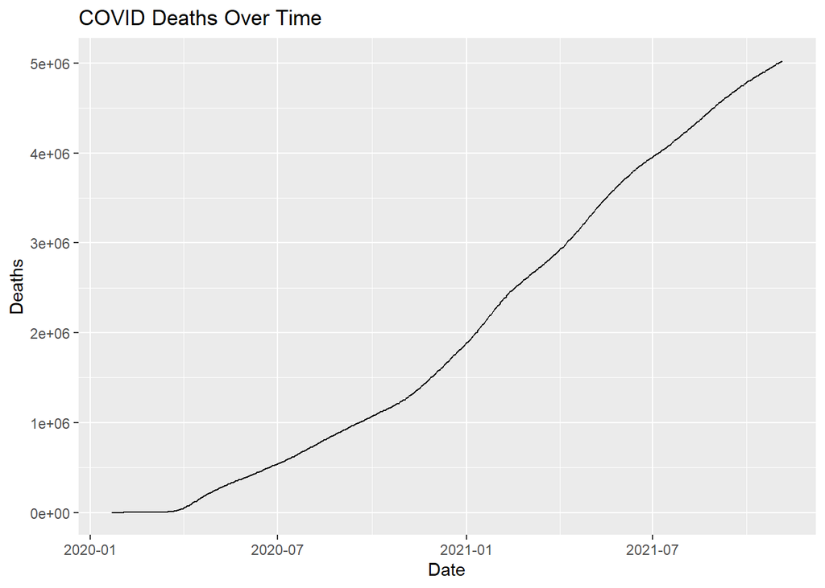

```r
ggplot(covid, aes(x=Date, y=Deaths)) +
  geom_line() + xlab("Date") + ylab("Deaths") +
  ggtitle("COVID Deaths Over Time")
```

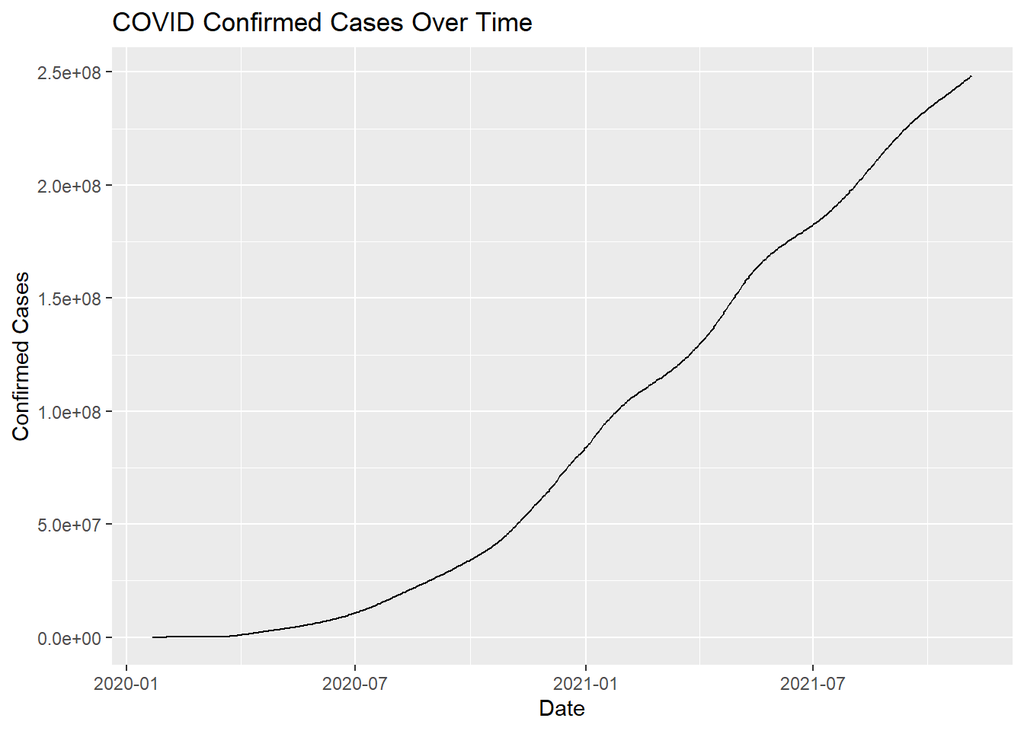

```r
ggplot(covid, aes(x=Date, y=Confirmed)) +
  geom_line() + xlab("Date") + ylab("Confirmed Cases") +
  ggtitle("COVID Confirmed Cases Over Time")
```

```r
#We can see that over time the deaths are increasing as well as the confirmed COVID cases.
```

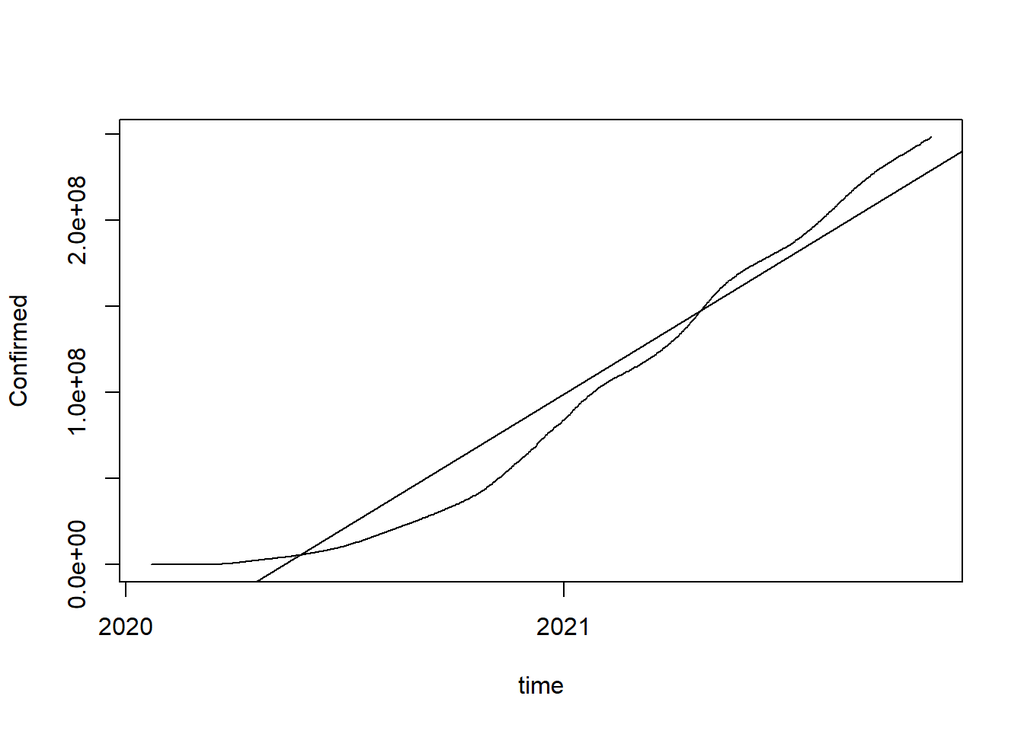

```r
y=world$Confirmed
x=world$Deaths
time=world$Date

y.lm=lm(y~time)
plot(world$Date,y, type='l', xlab='time', ylab='Confirmed')
abline(reg=y.lm)
```

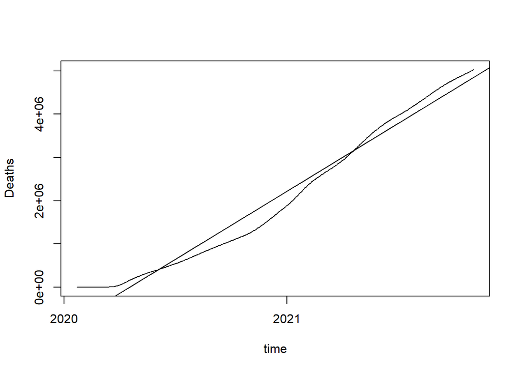

```r
x.lm=lm(x~time)
plot(world$Date,x, type='l', xlab='time', ylab='Deaths')
abline(reg=x.lm)
```

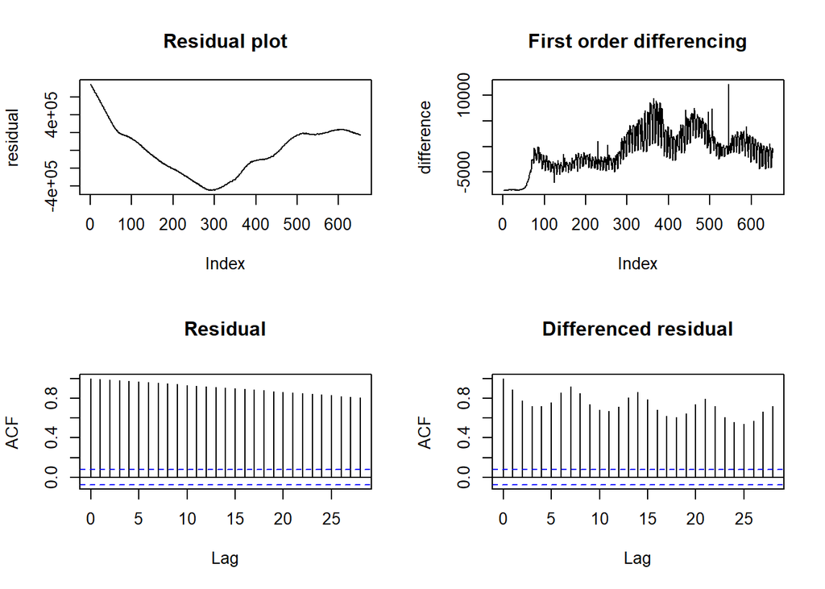

```r
par(mfrow=c(2,2))
res=resid(x.lm)
plot(res, type='l', ylab = 'residual', main='Residual plot')
plot(diff(res), type='l', ylab="difference", main = 'First order differencing')
acf(res, main='Residual')
acf(diff(res), main="Differenced residual")
```

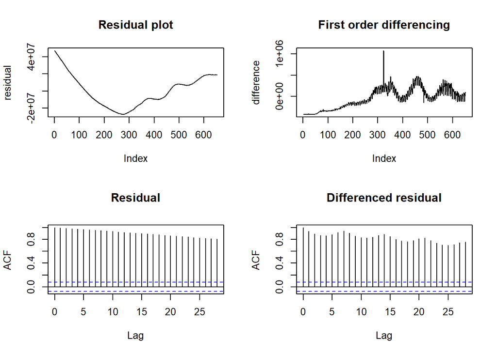

```r
par(mfrow=c(2,2))
res=resid(y.lm)
plot(res, type='l', ylab = 'residual', main='Residual plot')
plot(diff(res), type='l', ylab="difference", main = 'First order differencing')
acf(res, main='Residual')
acf(diff(res), main="Differenced residual")
```

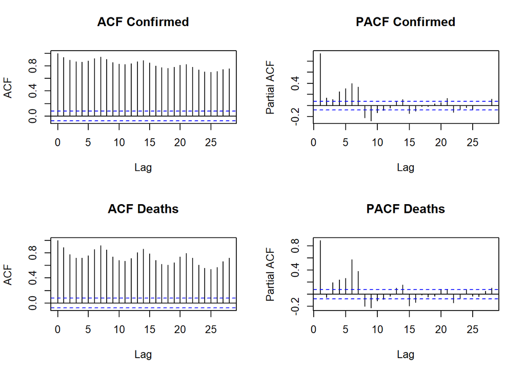

```r
#1st difference, acf, pacf
par(mfrow=c(2,2))
acf(diff(y), main='ACF Confirmed')
pacf(diff(y), main='PACF Confirmed')
acf(diff(x), main='ACF Deaths')
pacf(diff(x), main='PACF Deaths')
```

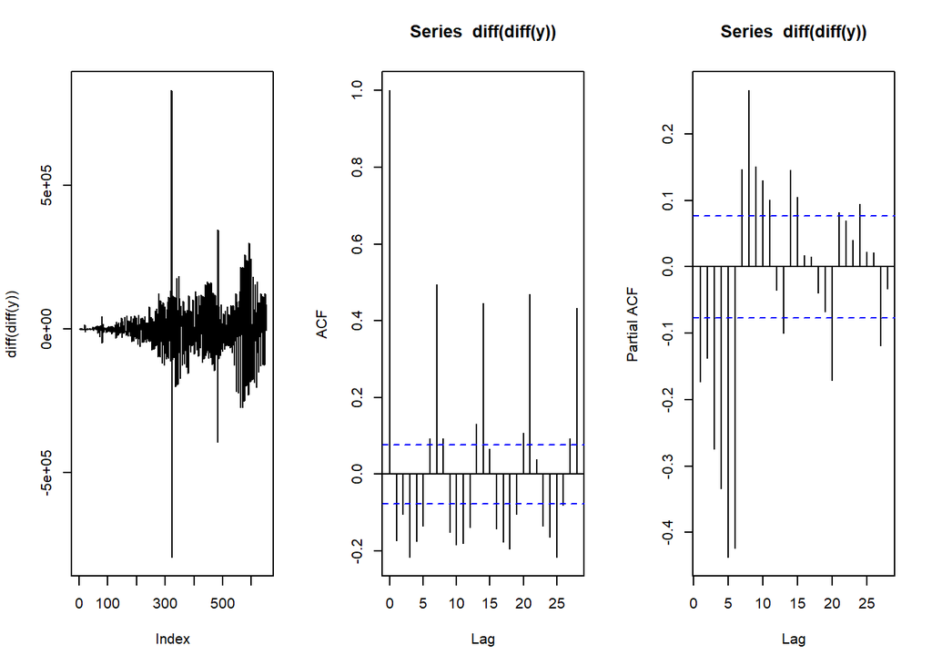

```r
par(mfrow=c(1,3))
#plot 2nd difference, acf, pacf
plot(diff(diff(y)), type='l')
acf(diff(diff(y)))
pacf(diff(diff(y)))
```

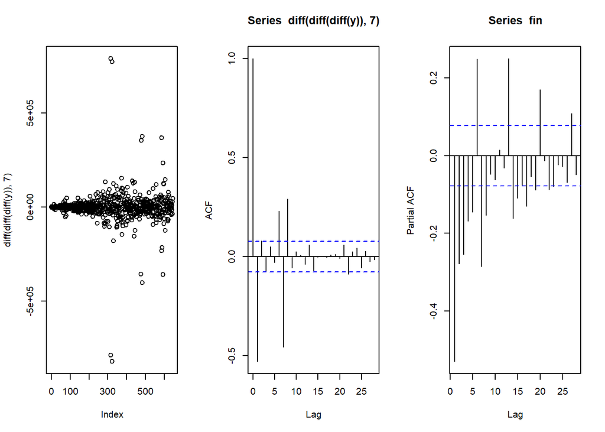

```r
#plot 1st seasonal difference, acf, pacf
plot(diff(diff(diff(y)), 7))
acf(diff(diff(diff(y)), 7))
fin = diff(diff(diff(y)), 7)
pacf(fin)
```

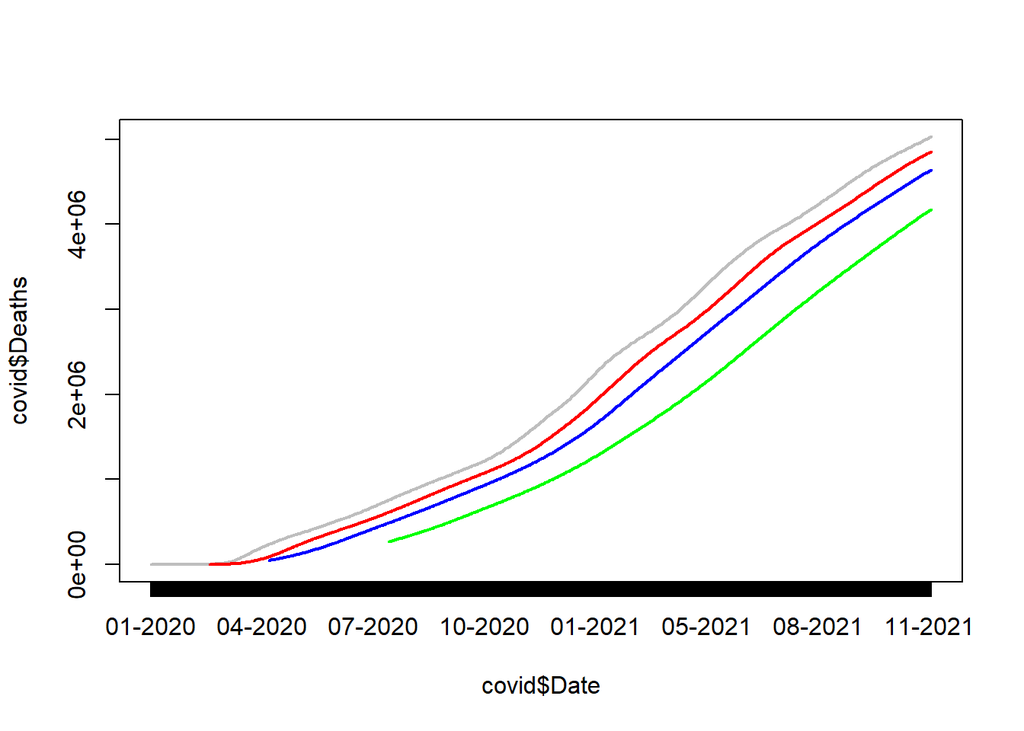

```r
# Moving averages - day 50, 100, and 200:
covid$Date <- as.Date(covid$Date, "%Y-%m-%d")
plot(covid$Date, covid$Deaths, xaxt="n", type="l", col="gray", lwd=2)
axis(1, covid$Date, format(covid$Date, "%m-%Y"))
lines(covid$Date, zoo::rollmean(covid$Deaths, 50, align='right', fill=NA), col='red', lwd=2)
lines(covid$Date, zoo::rollmean(covid$Deaths, 100, align='right', fill=NA), col='blue', lwd=2)
lines(covid$Date, zoo::rollmean(covid$Deaths, 200, align='right', fill=NA), col='green', lwd=2)
```

```r
library(xts)
```

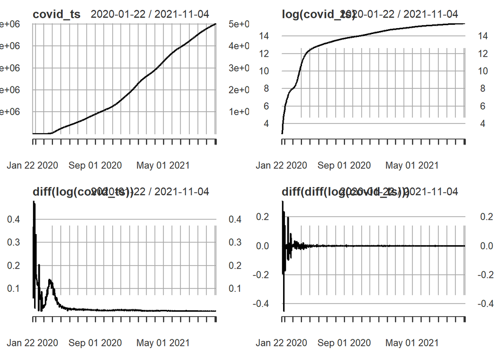

```r
covid_ts = xts(covid$Deaths, as.Date(covid$Date, format='%Y-%m-%d'))

par(mfrow=c(2,2))
plot(covid_ts)
plot(log(covid_ts))
plot(diff(log(covid_ts)))
plot(diff(diff(log(covid_ts))))
```

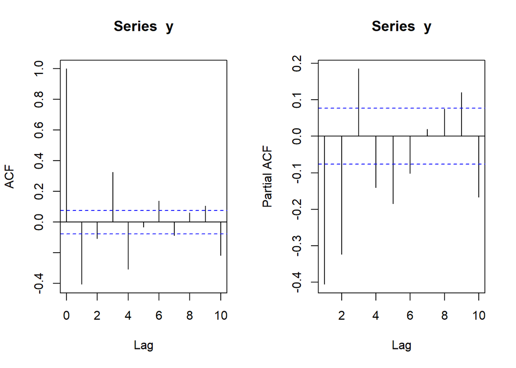

```r
y = diff(diff(log(covid_ts)))

par(mfrow=c(1, 2))
acf(y, lag.max=10, na.action=na.pass)
pacf(y, lag.max=10, na.action=na.pass)
```

From this we can see that the data is not normally distributed and it becomes stationary after being differenced twice. We can also see that there is no clear cut off for the ACF nor PACF.

```r
MA = arima(covid_ts, order = c(0, 0, 1))
MA_fit = covid_ts - residuals(MA)
```

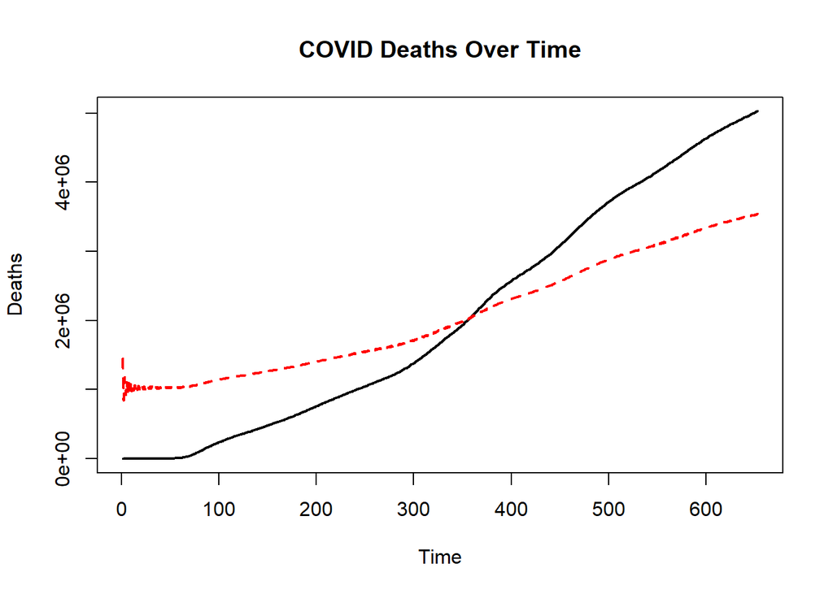

```r
plot.ts(covid_ts, ylab="Deaths", main="COVID Deaths Over Time", lwd=2)
points(MA_fit, type = "l", col = "red", lty = 2, lwd=2)
```

```r
MA_diff = arima(covid_ts, order = c(0, 1, 1))
MA_diff_fit = covid_ts - residuals(MA_diff)
```

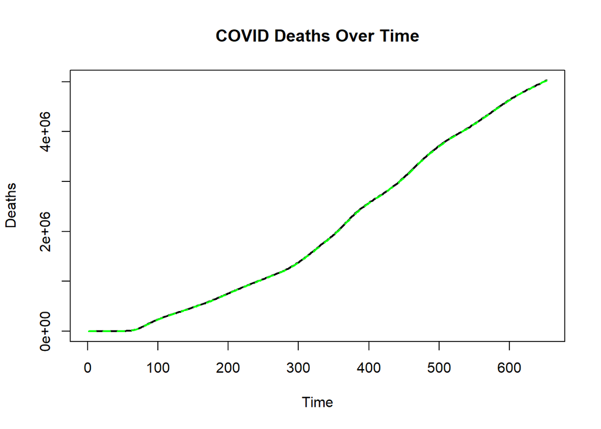

```r
plot.ts(covid_ts, ylab="Deaths", main="COVID Deaths Over Time", lwd=2)
points(MA_diff_fit, type = "l", col = "green", lty = 2, lwd=2)
```

For the MA model we look at the date vs deaths. We can see that the MA(1) fit is not very good and that it looks much better after differencing.

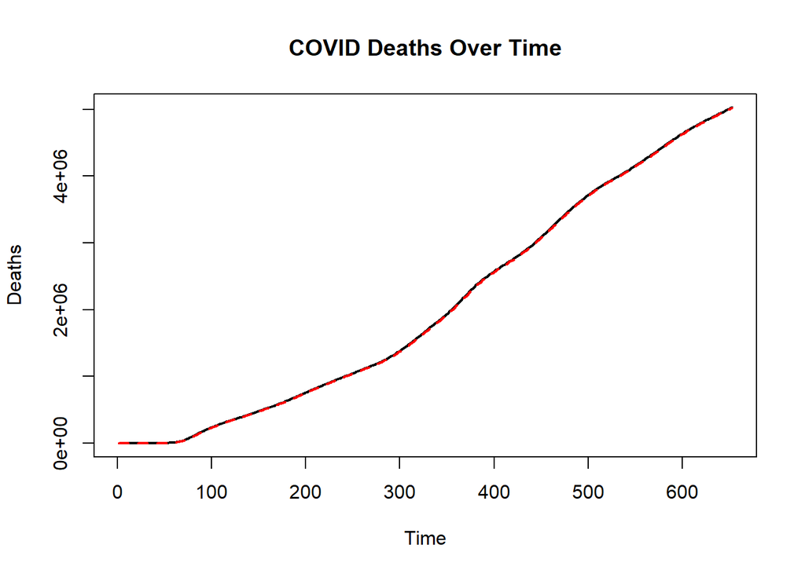

```r
plot.ts(covid_ts, ylab="Deaths", main="COVID Deaths Over Time", lwd=2)
AR <- arima(covid_ts, order = c(1,0,0))
AR_fit <- covid_ts - residuals(AR)
points(AR_fit, type = "l", col = "red", lty = 2, lwd=2)
```

```r
predict_AR <- predict(AR, n.ahead=12)
predict_AR$pred
```

```
## Time Series:
## Start = 654
## End = 665
## Frequency = 1
##  [1] 5029323 5029321 5029318 5029316 5029314 5029312 5029310 5029308
##  [9] 5029305 5029303 5029301 5029299
```

For the AR model we also look at the date vs deaths. We can see that the AR(1) fit looks pretty good but compare it to the MA model.

```r
AIC(AR) # 13,103.2
```

```
## [1] 13701.63
```

```r
AIC(MA_diff)  # 12,398.28
```

```
## [1] 12960.51
```

```r
AIC(MA) # 18,712.88
```

```
## [1] 19652.59
```

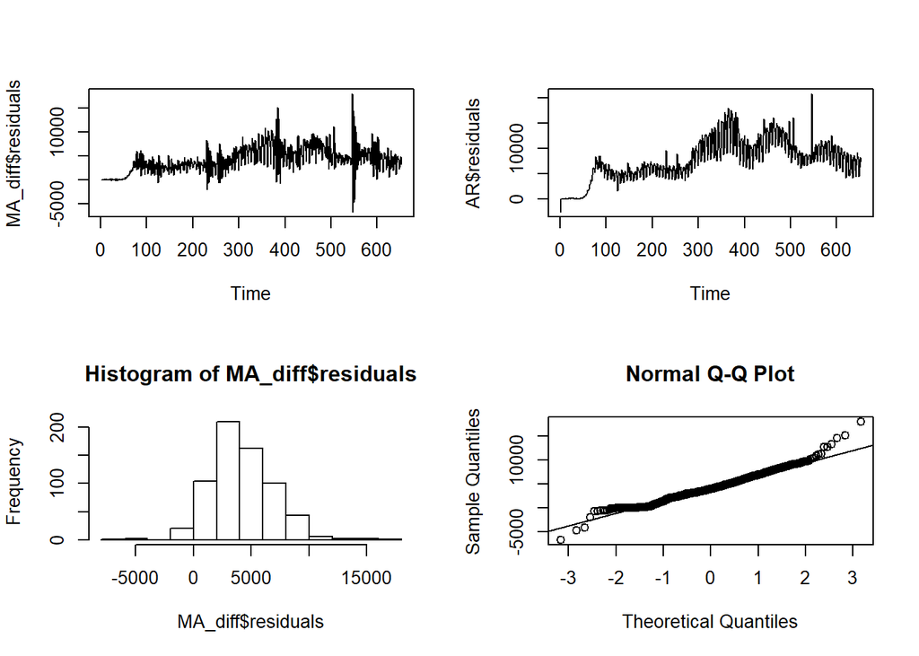

```r
par(mfrow=c(2,2))
plot(MA_diff$residuals)
plot(AR$residuals)

hist(MA_diff$residuals)
qqnorm(MA_diff$residuals)
qqline(MA_diff$residuals)
```

We can also see that the residuals have some trend but look fairly normal. By comparing the AICs we can see that the MA(1) with differencing = 1 has the lowest AIC. However, the AICs are fairly large leading us to believe that neither MA or AR models are fit for this data.

## Statistical results and conclusions from models and methods

# Research Question #1: Are confirmed cases linearly correlated with deaths?

```r
cor(covid$Confirmed, covid$Deaths)
```

```
## [1] 0.9975087
```

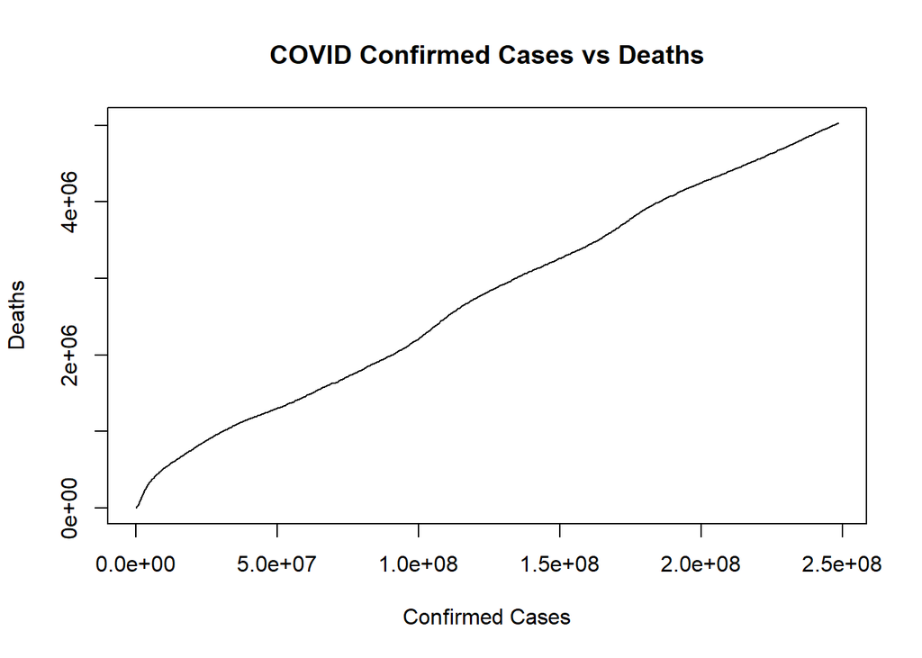

```r
plot(covid$Confirmed, covid$Deaths, xlab="Confirmed Cases", ylab="Deaths", main="COVID Confirmed Cases vs Deaths", type='l')
```

Yes, confirmed cases and deaths appear to have a linear relationship and have a high correlation of 0.997.

# Research Question #2: How does the trend of covid cases change based on geographic location?

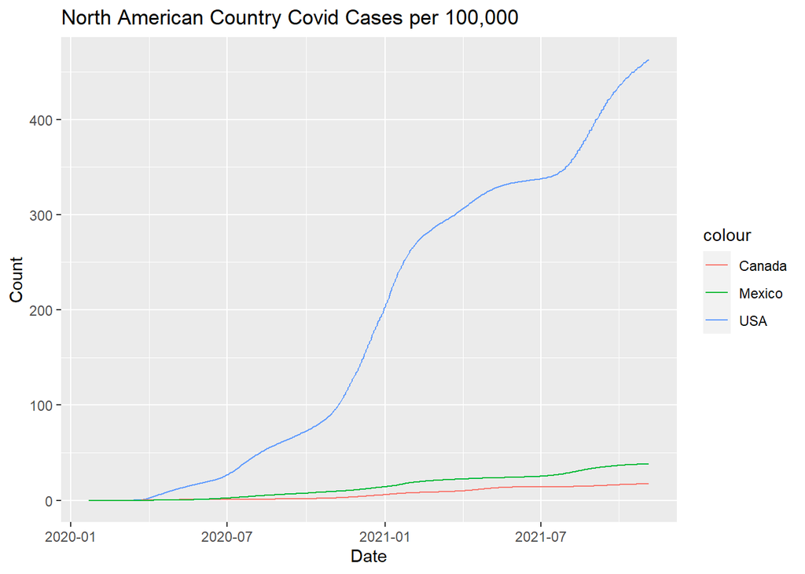

```r
### North American Countries
us_country <- countries[countries$Country == "US",]
canada <- countries[countries$Country == "Canada",]
mexico <- countries[countries$Country == "Mexico",]

us_country$Date=with_tz(us_country$Date, "America/New_York")
canada$Date=with_tz(canada$Date, "America/New_York")
mexico$Date=with_tz(mexico$Date, "America/New_York")

us_country$per = us_country$Confirmed/100000
canada$per = canada$Confirmed/100000
mexico$per = mexico$Confirmed/100000

(ggplot(us_country, aes(x = Date, y = `per`)) +
  geom_line(aes(y = `per`, color = "USA"))  +
  geom_line(data = canada, aes(color = "Canada")) +
  geom_line(data = mexico, aes(color = "Mexico")) +
  xlab('Date') +
  ylab('Count') +
  ggtitle('North American Country Covid Cases per 100,000'))
```

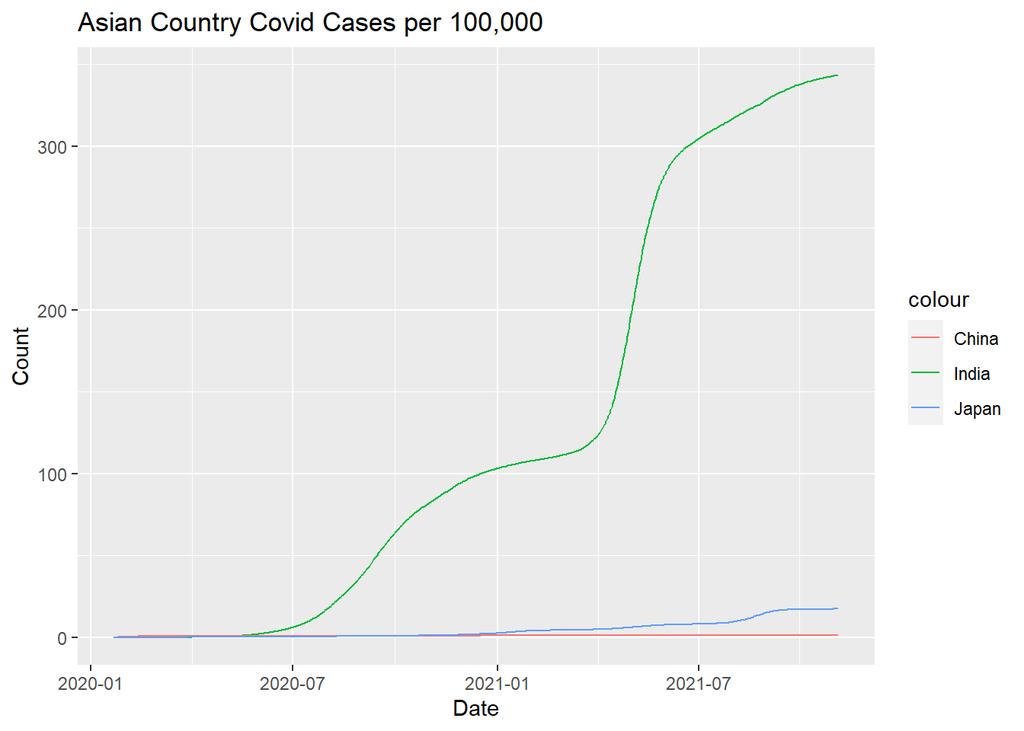

```r
### Asian Countries
india <- countries[countries$Country == "India",]
china <- countries[countries$Country == "China",]
japan <- countries[countries$Country == "Japan",]

india$Date=with_tz(india$Date, "America/New_York")
china$Date=with_tz(china$Date, "America/New_York")
japan$Date=with_tz(japan$Date, "America/New_York")

india$per = india$Confirmed/100000
china$per = china$Confirmed/100000
japan$per = japan$Confirmed/100000


(ggplot(india, aes(x = Date, y = `per`)) +
  geom_line(aes(y = `per`, color = "India"))  +
  geom_line(data = china, aes(color = "China")) +
  geom_line(data = japan, aes(color = "Japan")) +
  xlab('Date') +
  ylab('Count') +
  ggtitle('Asian Country Covid Cases per 100,000'))
```

As seen by the graphs, there seems to be a high count of COVID-19 cases in the United States and India. While these two countries are in different geographic locations, it seems as though the quarantining policy wasn’t strict enough, wasn’t enforced properly, or wasn’t followed in these two countries. Further research will need to be done to see if there is a change in trend based on geographic location. However, it is more likely based on this analysis that a refinement to the research question could be made to measure the difference in COVID-19 case trends in countries based on the strictness of their quarantining policies.

# Research Question #3: How can we predict the number of covid cases with forecasting?

```r
countries<- read_csv("data/countries-aggregated.csv")
world <- read_csv("data/worldwide-aggregate.csv")
```

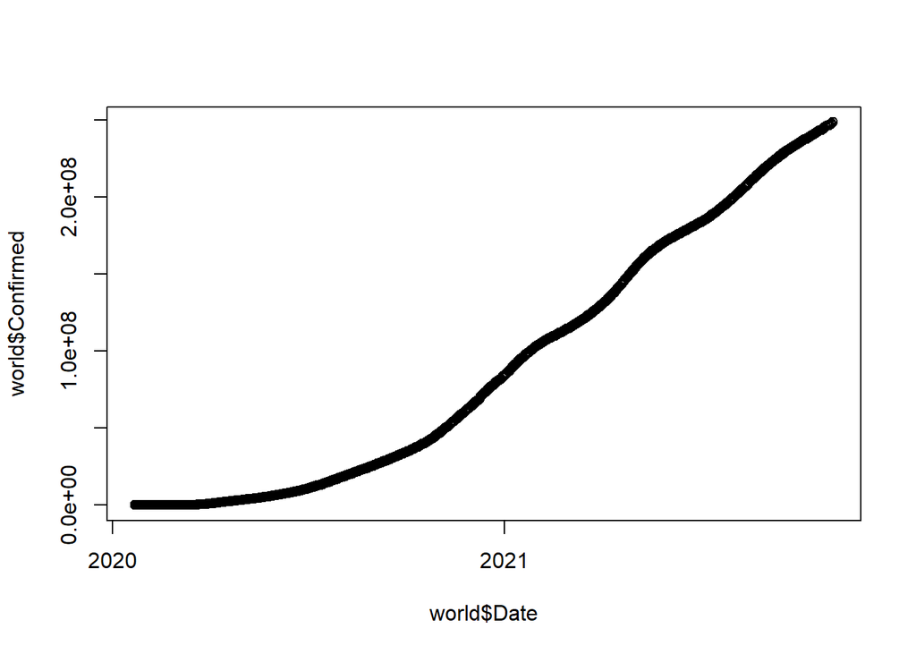

```r
#explaratory analysis (de-trend confirmed cases)
#initial plot
plot(world$Date, world$Confirmed)
```

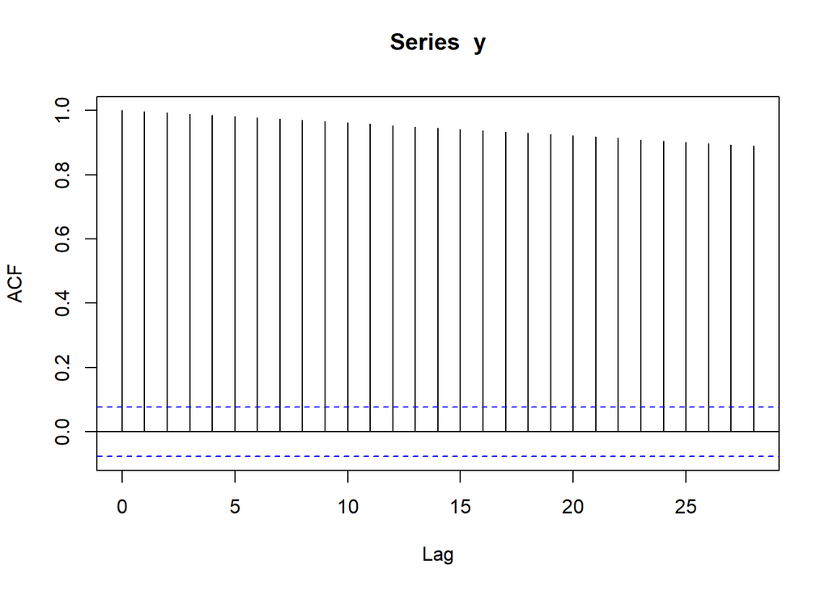

```r
y=world$Confirmed
time=world$Date
acf(y)
```

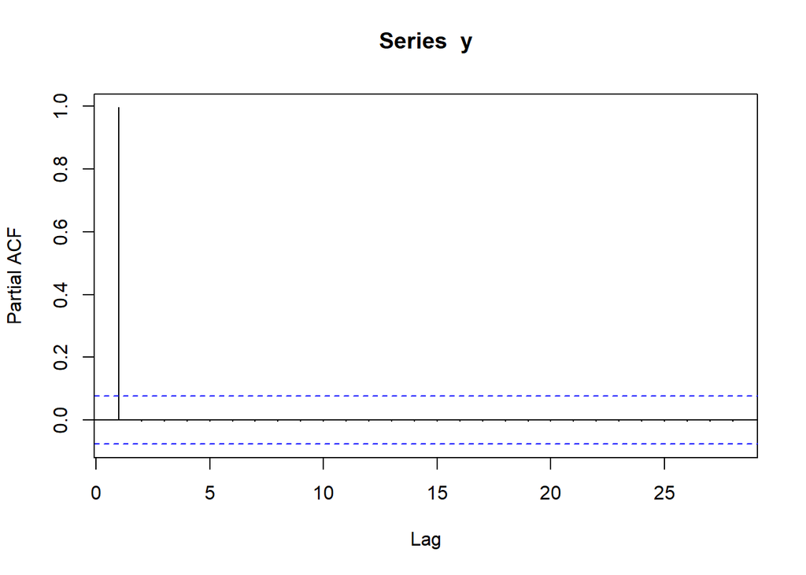

```r
pacf(y)
```

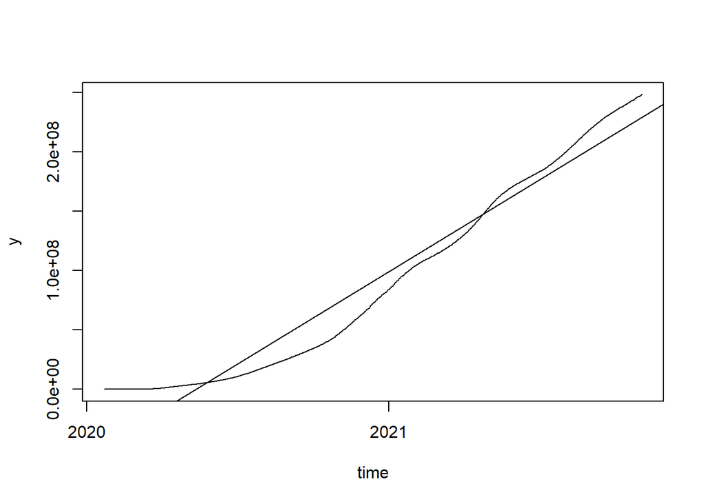

```r
#regression to de-trend
y.lm=lm(y~time)
plot(world$Date,y, type='l', xlab='time')
abline(reg=y.lm)
```

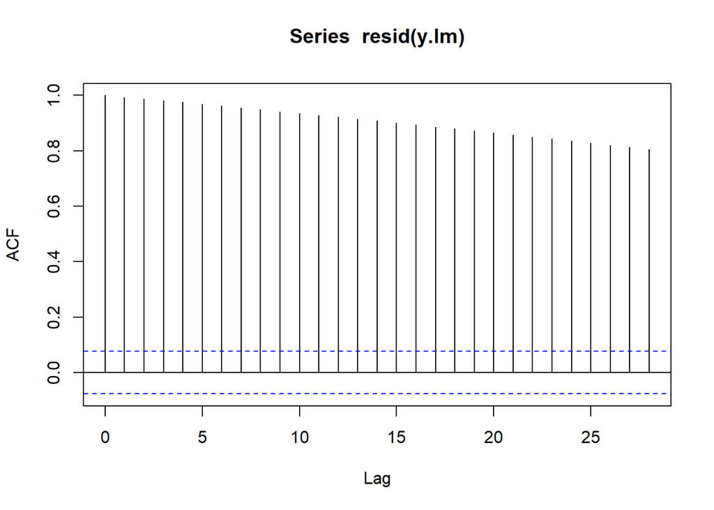

```r
#check acf after regression
acf(resid(y.lm))
```

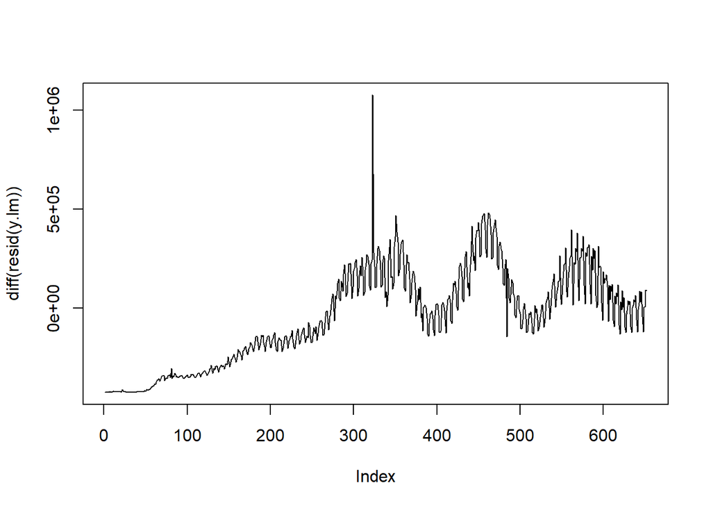

```r
#detrend through difference
plot(diff(resid(y.lm)), type='l')
```

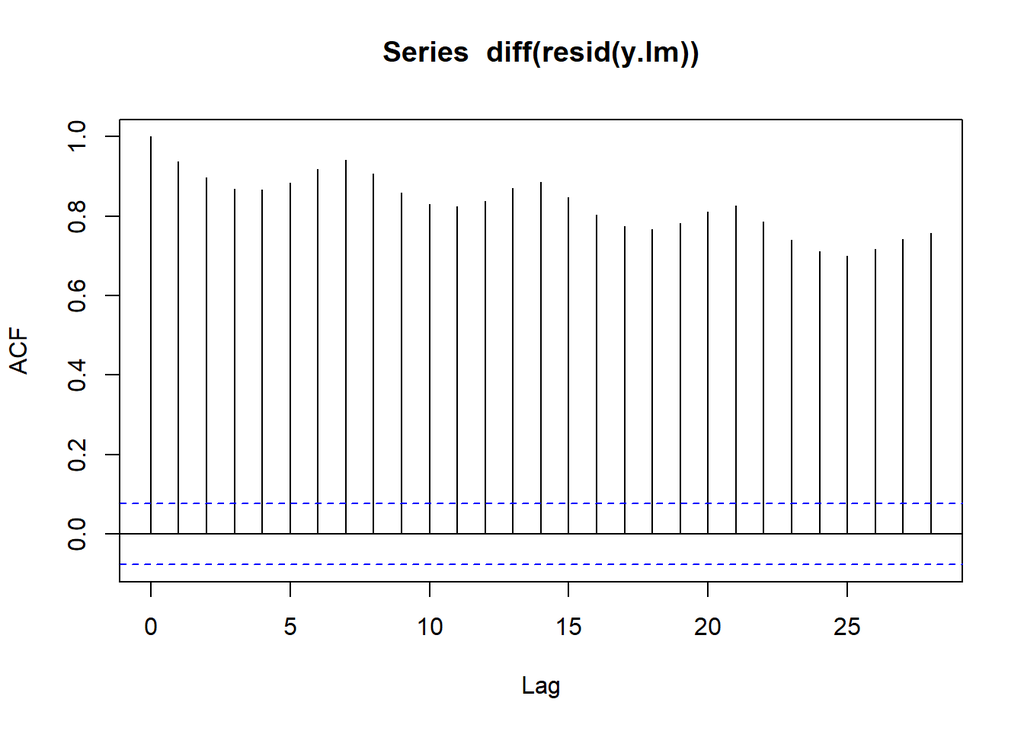

```r
acf(diff(resid(y.lm)))
```

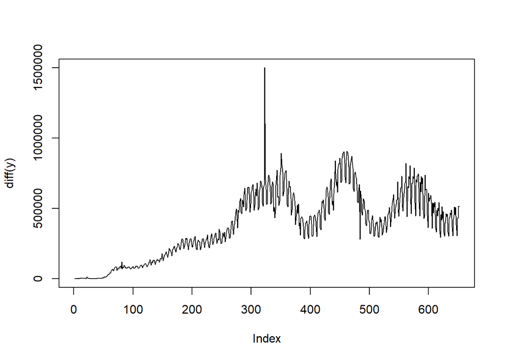

```r
#plot 1st difference, acf, pacf
plot(diff(y), type='l')
```

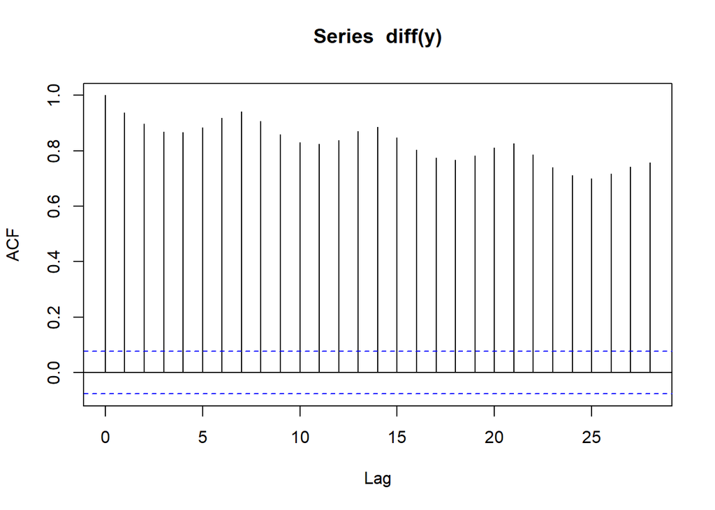

```r
acf(diff(y))
```

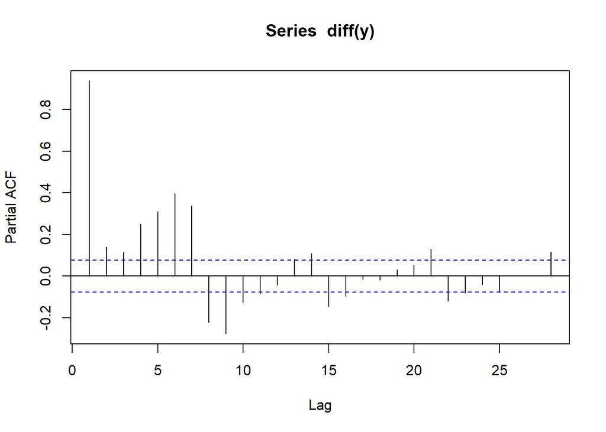

```r
pacf(diff(y))
```

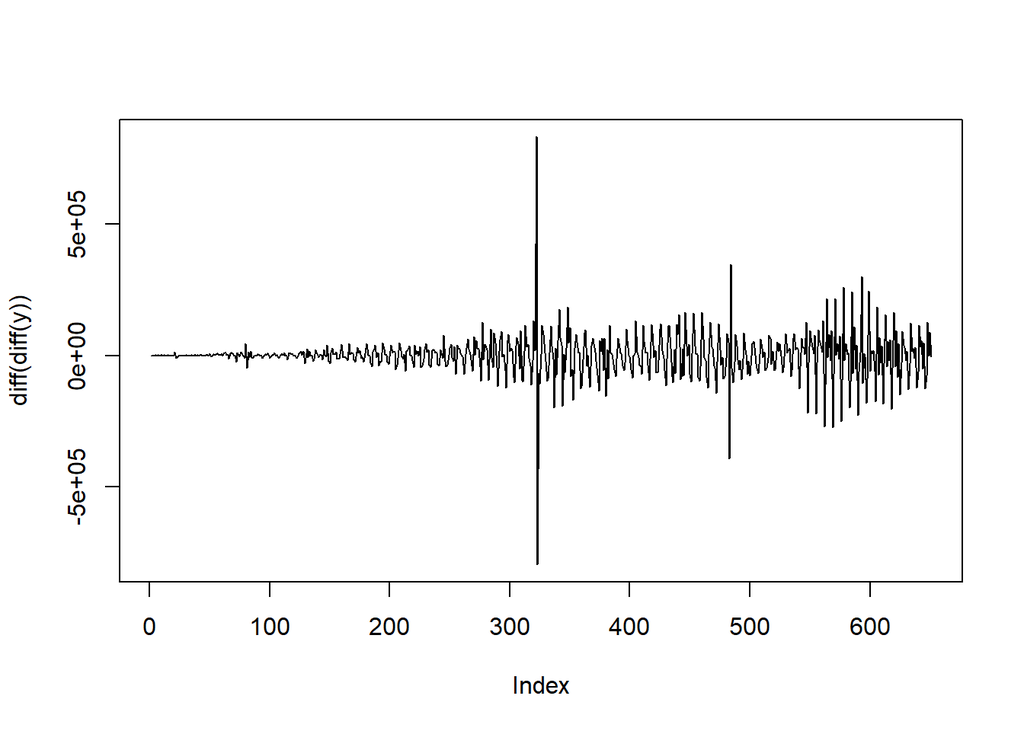

```r
#plot 2nd difference, acf, pacf
plot(diff(diff(y)), type='l')
```

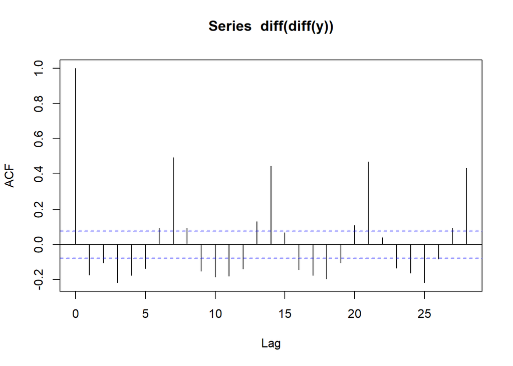

```r
acf(diff(diff(y)))
```

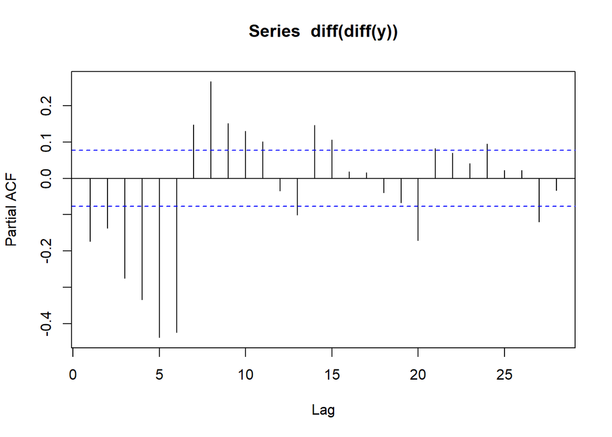

```r
pacf(diff(diff(y)))
```

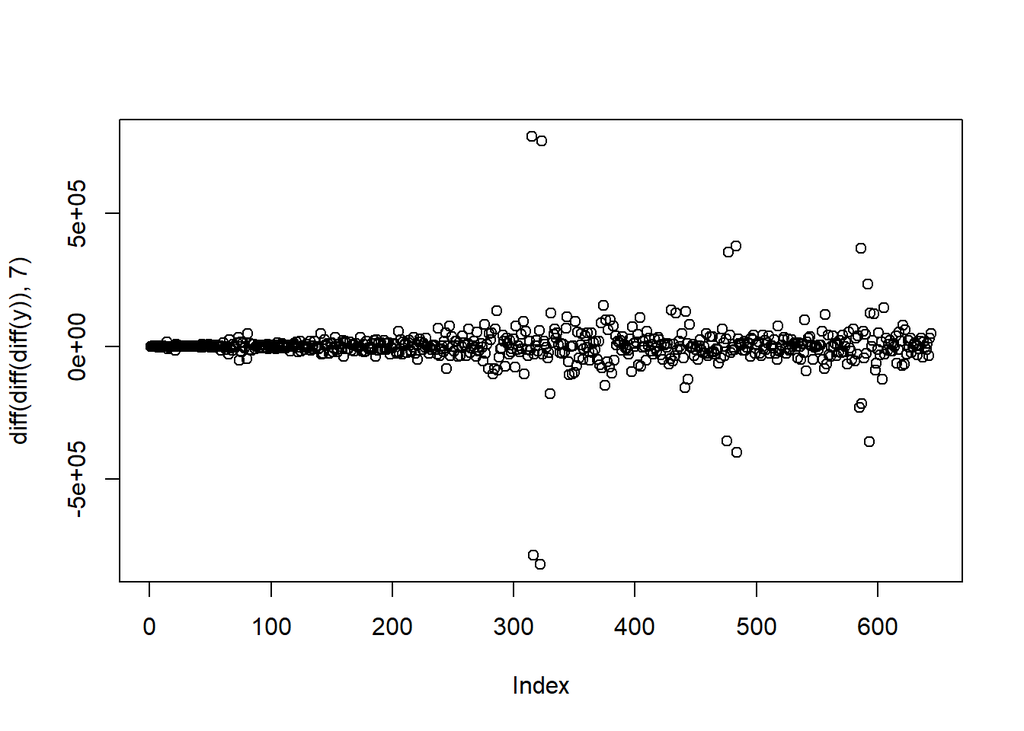

```r
#plot 1st seasonal difference, acf, pacf
plot(diff(diff(diff(y)), 7))
```

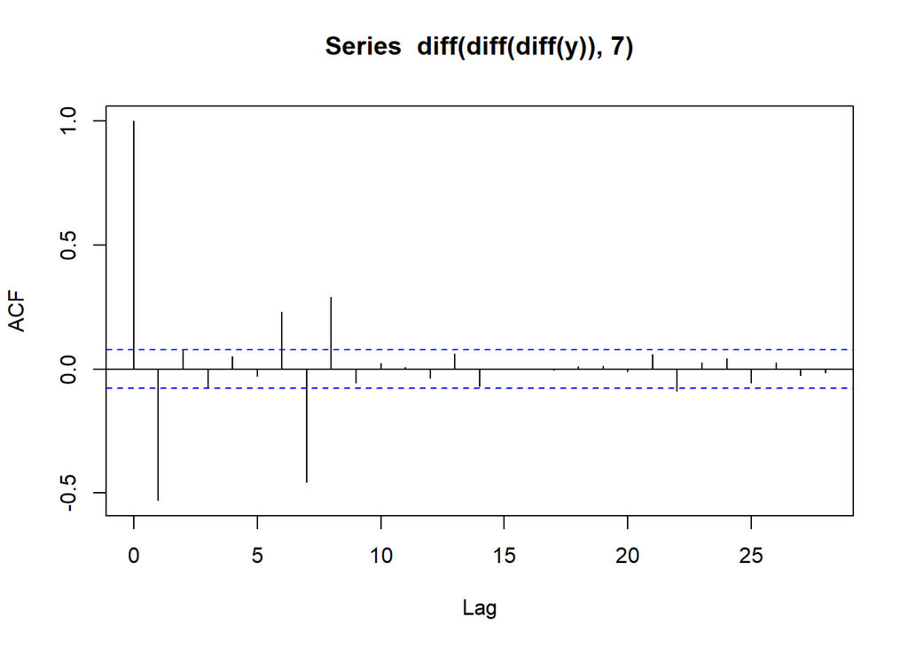

```r
acf(diff(diff(diff(y)), 7))
```

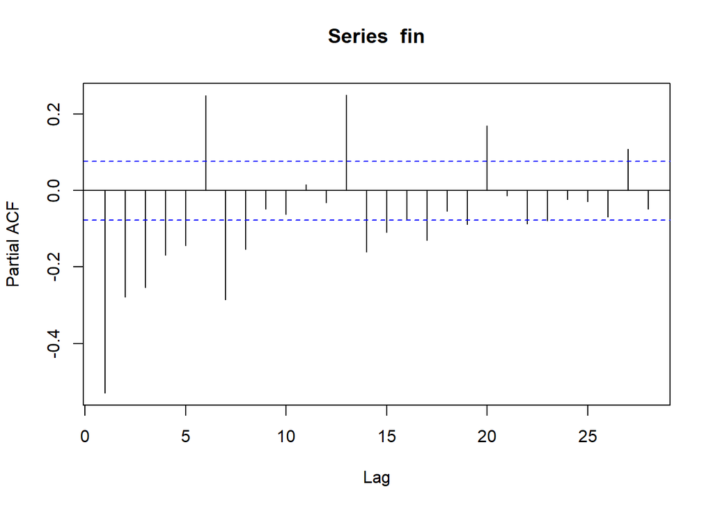

```r
fin = diff(diff(diff(y)), 7)
pacf(fin)
```

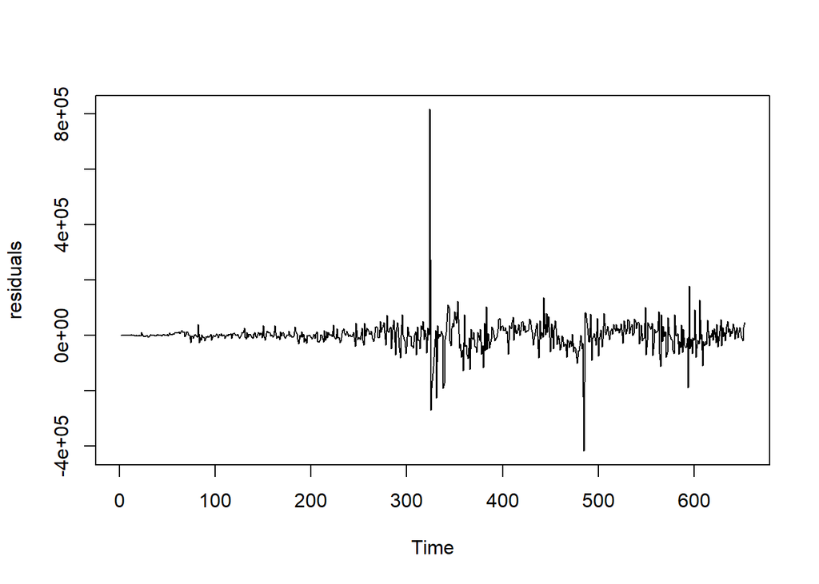

```r
confirmed.arima1 = arima(y, order=c(0, 2,1), seasonal=list(order=c(0, 1,1), period=7))

plot(confirmed.arima1$residuals, ylab = 'residuals')
```

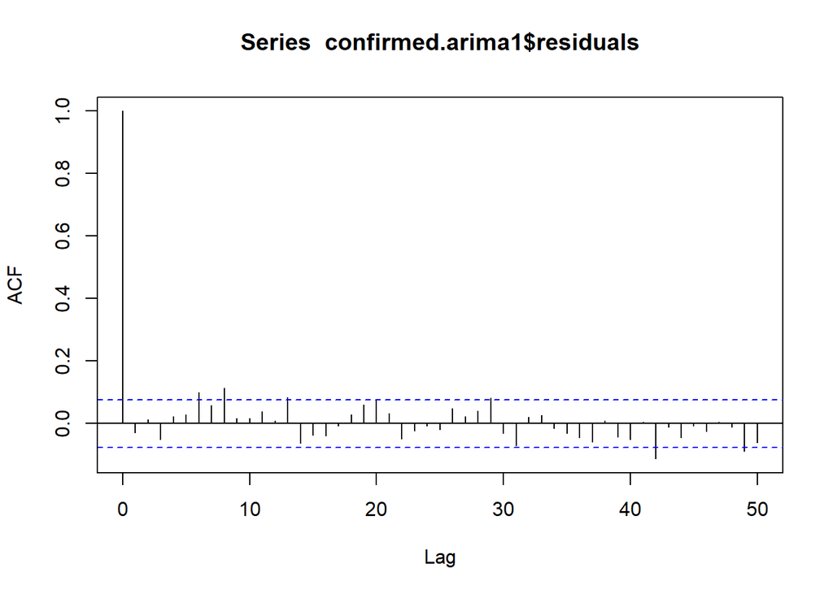

```r
acf(confirmed.arima1$residuals, lag.max  = 50, na.action=na.pass)
```

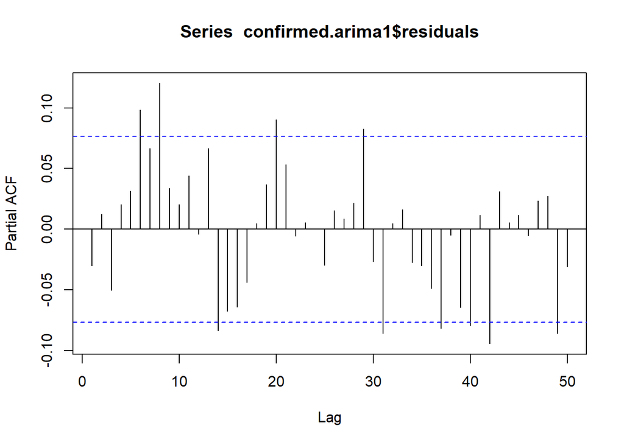

```r
pacf(confirmed.arima1$residuals, lag.max  = 50, na.action=na.pass)
```

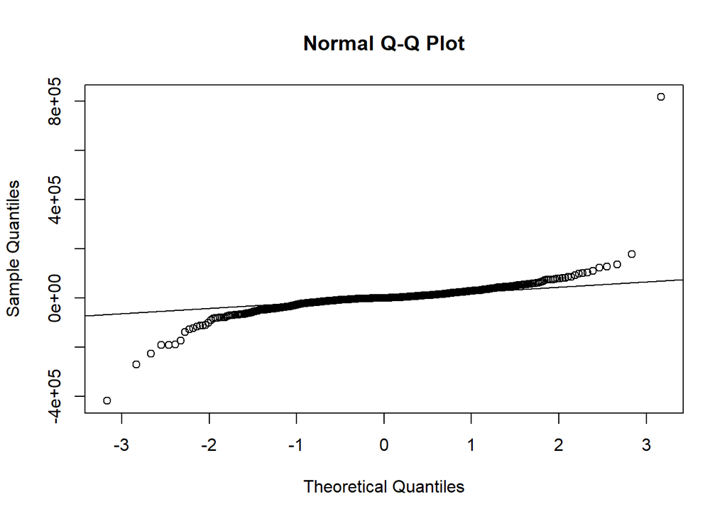

```r
qqnorm(confirmed.arima1$residual)
qqline(confirmed.arima1$residual)
```

```r
Box.test(confirmed.arima1$residuals, fitdf=1, lag = 20, type="Ljung")
```

```
##
##  Box-Ljung test
##
## data:  confirmed.arima1$residuals
## X-squared = 37.838, df = 19, p-value = 0.006223
```

```r
confirmed.arima1$aic
```

```
## [1] 15888.83
```

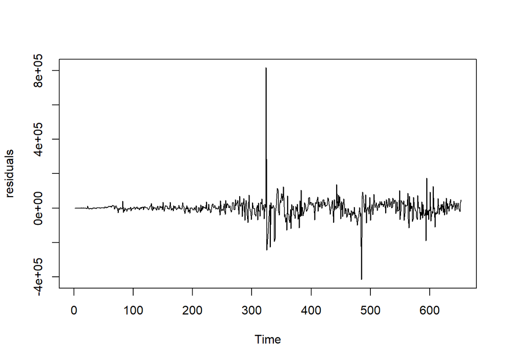

```r
confirmed.arima2 = arima(y, order=c(0, 2,2), seasonal=list(order=c(0, 1,1), period=7))

plot(confirmed.arima2$residuals, ylab = 'residuals')
```

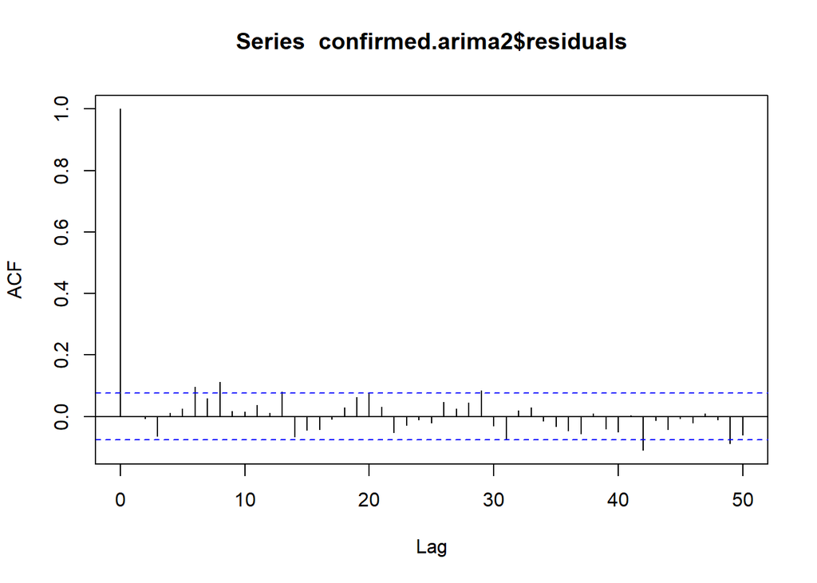

```r
acf(confirmed.arima2$residuals, lag.max  = 50, na.action=na.pass)
```

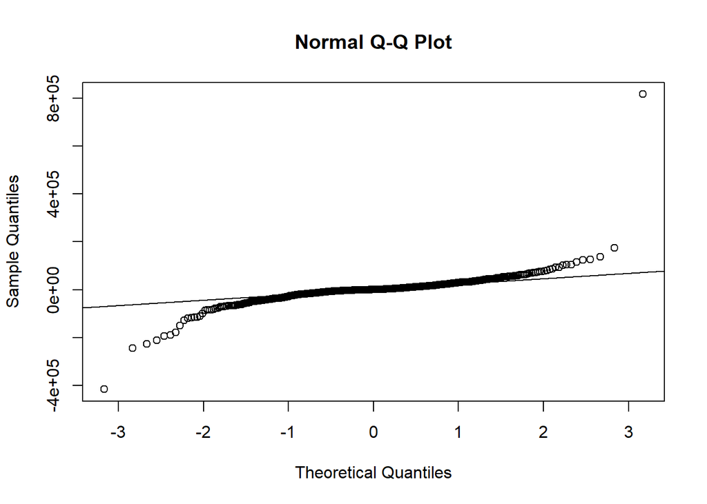

```r
qqnorm(confirmed.arima2$residual)
qqline(confirmed.arima2$residual)
```

```r
confirmed.arima2$aic
```

```
## [1] 15889.8
```